# EAI Practicum 2.3

## Classification Problems II.

In the following exercise we’ll use the FIFA data set containing information on 19 239 players enrolled in the season of 22, including columns related to: player’s `role`, `player_positions`, `preferred_foot` and `skills`.

### Modelling Aims

Our previous goal was to discriminate **offensive** **players** from **all other players** based on information we have on them, such as **skill** characteristics, **foot preference**, etc. You created an ordinary logistic regression model that performed a binary classification of football players.

In this exercise, we will explore the logistic regression topic further by applying methods that can tell you how good your binary classifier was. This will require you to:

- understand your data so as not to be surprised if your classifier does not work,
- perform binary classification using probability-based cut-off,
- cross-tabulate binary and real outcomes,
- understand the concept of a contingency table and statistics that can be calculated from it,
- Use ROC and auROC to see if there exist a better probability cut-off (compared to default 50%)
- Apply new cut-off and re-evaluate model performance statistics

### Model Preparation

This exercise follows up on the previous exercise. Load `players_22.csv` data into R and re-apply all necessary steps to generate a logistic regression `model`. Review the model parameters so that we are on the same page. By running:

```r
 model <- glm(data$role_oneHot ~ data$skill_dribbling + data$preferred_foot, family = binomial)
 summary(model)
```

You should get the following readout:

```
##
## Call:
## glm(formula = data$role_oneHot ~ data$skill_dribbling + data$preferred_foot,
##     family = binomial)
##
## Coefficients:
##                           Estimate Std. Error z value Pr(>|z|)
## (Intercept)              -6.228878   0.120081 -51.872  < 2e-16 ***
## data$skill_dribbling      0.092746   0.001793  51.712  < 2e-16 ***
## data$preferred_footRight  0.209373   0.039042   5.363 8.19e-08 ***
## ---
## Signif. codes:  0 '***' 0.001 '**' 0.01 '*' 0.05 '.' 0.1 ' ' 1
##
## (Dispersion parameter for binomial family taken to be 1)
##
##     Null deviance: 25528  on 19238  degrees of freedom
## Residual deviance: 20262  on 19236  degrees of freedom
## AIC: 20268
##
## Number of Fisher Scoring iterations: 5
```

### Cross-Tabulate Binary Outcomes

**Task 1:** Extract one-hot-encoded player roles from model `object` or `data` (hint: these data exist in both).

```r
real.classes <- ... # Fill in your code here
```

**Task 2:** Extract class probabilities from the `model` object. Use a 50% cut-off value to classify players into offensive and defensive groups. Save the resulting vector as `predicted.classes`.

```r
predicted.class.probabilities <- ... # Fill in your code here
predicted.classes <-... # Fill in your code here

map_df(list(Real.Classes = real.classes,
            Predicted.Probabilities = predicted.class.probabilities,
            Predicted.CLasses = predicted.classes), head)
```

[output not shown]

**Task 3:** Cross-tabulate real and predicted classes. Use `confusionMatrix()` from the caret package. `confusionMatrix()` accepts `predicted.classes` and `real.classes` as factors. Be sure to define how positive classes are encoded.

```r
library(caret)
caret::confusionMatrix(..., ..., positive = "1")
```

```
## Confusion Matrix and Statistics
##
##           Reference
## Prediction    0    1
##          0 9372 3201
##          1 2580 4086
##
##                Accuracy : 0.6995
##                  95% CI : (0.693, 0.706)
##     No Information Rate : 0.6212
##     P-Value [Acc > NIR] : < 2.2e-16
##
##                   Kappa : 0.3507
##
##  Mcnemar's Test P-Value : 3.51e-16
##
##             Sensitivity : 0.5607
##             Specificity : 0.7841
##          Pos Pred Value : 0.6130
##          Neg Pred Value : 0.7454
##              Prevalence : 0.3788
##          Detection Rate : 0.2124
##    Detection Prevalence : 0.3465
##       Balanced Accuracy : 0.6724
##
##        'Positive' Class : 1
##
```

**Task 4:** Inspect the readout. Which of the above statistics have you computed in the last task of **EIA Lab 2.2**?

### Understanding Model Performance

The performance of ML algorithms is measured using a set of evaluation metrics, with model **accuracy** being among the commonly used ones.

**Task 5:** Revisit the contingency table from EIA Lab 2.2. Come with a R code and formula to calculate the accuracy of your logistic regression model.

> Be aware that accuracy and other statistics are obtained for 50% probability cut-off and will be different for other cut-offs.

```r
contingencyTable <- ... # Fill in your code here
Accuracy = ... # Fill in your code here
paste(...) # Fill in your code here
```

```
##          real
## predicted    0    1
##         0 9372 3201
##         1 2580 4086
```

```
## [1] "Accuracy =  0.69951660689225"
```

**Accuracy** calculates the number of correct predictions made by a model across the entire dataset, which is valid when the dataset classes are balanced in size. In the past, accuracy was the sole criterion for comparing machine learning models.

**Task 6:** Use counts from the confusion matrix to calculate the proportion of each class. Are 0 (non-attackers) and 1 (attackers) balanced classes in your dataset?

```r
proportion.of.1 <- ... # Fill in your code here
proportion.of.0 <- ... # Fill in your code here
paste(...) # Fill in your code here
```

[output not shown]

### Precision and Accuracy

Today data scientists use the **precision** measure alongside **accuracy**. While accuracy assesses the proximity to the actual value of the measurement, precision indicates the proximity of the predicted values to each other.

The bullseye analogy is commonly used to illustrate the difference between accuracy and precision. Imagine you are throwing darts at a bullseye with the goal of achieving both accuracy and precision, meaning you want to consistently hit the bullseye. Accuracy refers to landing your throws near the bullseye, but not necessarily hitting it every time. On the other hand, precision means your throws cluster closely together, but they may not be near the bullseye. However, when you are both accurate and precise, your darts will consistently hit the bullseye.

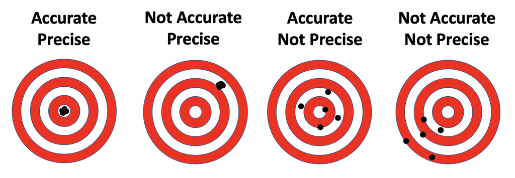